# DQN in Grid World

Junmo Nam

Grid World 문제를 DQN 및 DDQN(Double Deep Q-Network)을 활용하여 푸는 예제입니다.  
Reference :  
Van Hasselt, Hado, Arthur Guez, and David Silver. “Deep reinforcement learning with double q-learning.” Thirtieth AAAI Conference on Artificial Intelligence. 2016.

### 방법론 소개

#### DQN이란?

DQN은 고전 강화학습의 한계인 차원의 저주 및 계산문제를 해결하기 위해 딥러닝을 활용한 근사 방법과 Q learning을 결합한 방법론입니다.

#### DDQN이란?

DDQN은 Deep Q-learning의 단점인 overoptimistic(환경의 노이즈에 의해 q-learning에서 가치가 과대평가 되는 것)을 해결하기 위해 나온 방법론입니다. DDQN에서는 Q를 아래와 같은 방식으로 업데이트를 하게 됩니다.

Q-learning : $Q(s,a) <= R_{t+1} + discount*max(Q(S_{t+1},a))$  
Double Q-learning : $Q(s,a) <= R_{t+1} + discount*Q(S_{t+1},max(Q(S_{t+1},a)))$ 즉, 기존의 Q-learning에서 선택된 max 값에 따른 행동을 가지고 다시 Q함수에 입력하여 그 반환값을 max Q값 대신 활용하는 방식입니다.

### 환경 설정하기

#### 환경 초기화 및 패키지 로딩

환경에 남아있는 변수들을 제거하고, gc 및 사용할 패키지들을 로딩합니다.

```r
# reset session
rm(list = ls())
gc(reset = T)
```

```
##           used (Mb) gc trigger (Mb) max used (Mb)
## Ncells  528037 28.3    1204102 64.4   528037 28.3
## Vcells 1031665  7.9    8388608 64.0  1031665  7.9
```

```r
# load package
sapply(c("dplyr", "ggplot2", "keras", "devtools", "reshape2"), require, character.only = T)
```

```
##    dplyr  ggplot2    keras devtools reshape2
##     TRUE     TRUE     TRUE     TRUE     TRUE
```

#### 그리드 문제 설정

찾을 그리드 및 학습 파라미터들을 설정해줍니다.

```r
#claim grid world environment
grid = matrix(0,5,5)
grid[5,5] = 1
grid[2,3:4] = -1;grid[4,3] = -1;grid[4,4]=-1;grid[5,1]=-1

#set episodes
episode = 1000

#claim DQN parameters
params = list(
  #define global variables
  discount = 0.99,
  learning_rate = 0.001,
  batch_size = 32,
  epsilon = 1, #random action parameter
  epsilon_decay = 0.999, #decaying weight
  epsilon_min = 0.01, #minimum of epsilon
  max_memory = 3000, #memory limit
  train_start = 1000 #number of row for training start standard
)
```

마지막으로, gist에 있는 소스 스크립트를 불러와줍니다.

```r
source_gist("https://gist.github.com/JunmoNam/bfc825e5163012118312a8ae3e0e5d66")
```

### DQN Agent

#### 학습

```r
# training
hist = double_dqn_agent(episode, params, grid, double = F)
```

#### 학습결과 정책화 및 시각화

학습된 정책은 predict 함수를 이용하여 보여줄 수 있으며, Q-learning 방식대로 max값을 찾아 행동을 하도록 합니다.  
해당 작업을 위해 먼저 predict 함수에 학습된 모델(hist$model)을 넣어준 후, 뒤에 expand.grid를 통해 만든 매트릭스(모든 가능한 state의 조합)를 넣어줍니다. 이를 통해 나온 결과 행렬을 max.col, 즉 행마다 최고값을 가진 칼럼을 선별하는 방식으로 정리를 해주면 아래와 같은 상태별 정책을 얻을 수 있습니다.

```r
predict(hist$model, expand.grid(state.x = 1:nrow(grid), state.y = 1:ncol(grid)) %>%
    data.matrix) %>% as.data.frame %>% mutate(action = c("up", "down", "left",
    "right")[max.col(.)]) %>% select(action) %>% cbind(expand.grid(x = 1:nrow(grid),
    y = 1:ncol(grid)), .)
```

| x | y | action |
| --- | --- | --- |
| 1 | 1 | down |
| 2 | 1 | down |
| 3 | 1 | down |
| 4 | 1 | right |
| 5 | 1 | right |
| 1 | 2 | down |
| 2 | 2 | down |
| 3 | 2 | down |
| 4 | 2 | down |
| 5 | 2 | right |

[output cut: 15 more lines]

시각화 함수는 고전 강화학습때의 방법과 유사하게 진행하나, 학습된 정책 대신 model을 인풋으로 집어넣습니다. 함수에서 해당 모델을 기반으로 예측한 정책을 가지고 그림을 그리게 됩니다. 마지막 옵션은 어떤 방법을 사용했는지 그래프에 보여주기 위한 것으로 DQN을 써줍니다.

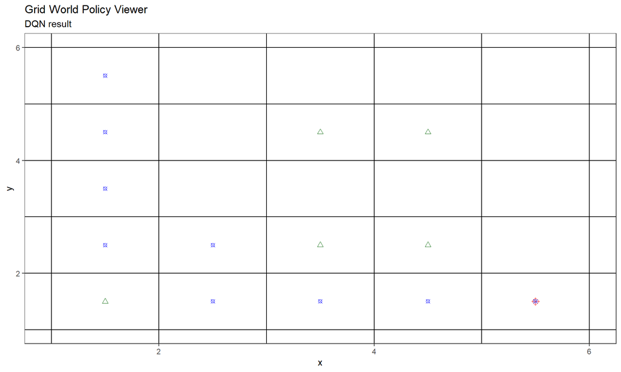

```r
draw_policy_model(grid, qmodel = hist$model, "DQN")
```

### DDQN Agent

#### 학습

```r
# training
hist = double_dqn_agent(episode, params, grid, double = T)
```

#### 학습결과 정책화 및 시각화

학습된 정책은 predict 함수를 이용하여 보여줄 수 있으며, Q-learning 방식대로 max값을 찾아 행동을 하도록 합니다.  
해당 작업을 위해 먼저 predict 함수에 학습된 모델(hist$model)을 넣어준 후, 뒤에 expand.grid를 통해 만든 매트릭스(모든 가능한 state의 조합)를 넣어줍니다. 이를 통해 나온 결과 행렬을 max.col, 즉 행마다 최고값을 가진 칼럼을 선별하는 방식으로 정리를 해주면 아래와 같은 상태별 정책을 얻을 수 있습니다.

```r
predict(hist$model, expand.grid(state.x = 1:nrow(grid), state.y = 1:ncol(grid)) %>%
    data.matrix) %>% as.data.frame %>% mutate(action = c("up", "down", "left",
    "right")[max.col(.)]) %>% select(action) %>% cbind(expand.grid(x = 1:nrow(grid),
    y = 1:ncol(grid)), .)
```

| x | y | action |
| --- | --- | --- |
| 1 | 1 | down |
| 2 | 1 | down |
| 3 | 1 | down |
| 4 | 1 | right |
| 5 | 1 | right |
| 1 | 2 | down |
| 2 | 2 | left |
| 3 | 2 | down |
| 4 | 2 | down |
| 5 | 2 | right |

[output cut: 15 more lines]

시각화 함수는 고전 강화학습때의 방법과 유사하게 진행하나, 학습된 정책 대신 model을 인풋으로 집어넣습니다. 함수에서 해당 모델을 기반으로 예측한 정책을 가지고 그림을 그리게 됩니다.

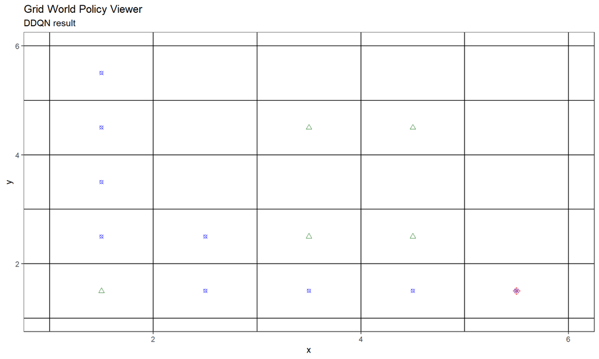

```r
draw_policy_model(grid, qmodel = hist$model, "DDQN")
```

### 소스파일 이해하기

소스 스크립트는 마크다운 하단 혹은 [GIST](https://gist.github.com/JunmoNam)의 DDQN.R에서 확인할 수 있습니다.

#### step 함수

페널티 주는 방식에 대해서는 [qmaze](https://www.samyzaf.com/ML/rl/qmaze.html)를 참고하였습니다. 그리드 밖으로 나갈 시 제자리로 돌아오며 -1.5 페널티를, 벽에 도달할 시 -1.75 페널티를 부여합니다.

```r
#step function for give information after do action
step = function(state,action){

  #x and y in state
  x = state$x
  y = state$y

  #do action
  if(x==1 & action == 'up'| x== nrow(grid) & action=='down'|
     y==1 & action == 'left'| y==ncol(grid) & action == 'right'){
    #action not allowed : penalty
    reward = -1.5
    next_state = state
  }else if(action == 'up'){
    reward = grid[x-1,y]
    next_state = list(x = x-1,y = y)
  }else if(action == 'down'){
    reward = grid[x+1,y]
    next_state = list(x = x+1,y = y)
  }else if(action == 'left'){
    reward = grid[x,y-1]
    next_state = list(x = x,y = y-1)
  }else{
    reward = grid[x,y+1]
    next_state = list(x = x,y = y+1)
  }

  if(reward==-1){ #face wall : go back
    reward = -1.75
    next_state = state
  }

  return(list(next_state = next_state,reward =  reward))
}
```

#### get_action 함수

qtable에서 주어진 state에 대해 필터한 후 max q값을 찾습니다. 중복일 경우 랜덤으로 하나를 샘플링하며, 기본적인 방식은 입실론-그리디 방법으로 동일합니다.

```r
#get action from given state
get_action = function(state,epsilon,qtable,actions){

  ifelse(sample(0:1,1,prob = c(epsilon,1-epsilon))==1, #epsilon check
         as.character((qtable %>% filter(x==state$x,y==state$y) %>% filter(q == max(q)) %>% sample_n(1))$action), #do max q action
         sample(actions,1))#random action
}
```

#### build_model 함수

학습을 위한 신경망을 생성하는 함수입니다. keras api의 sequential model 방식으로 30개의 노드를 가지는 layer 2개를 가지며 첫 input shape는 상태의 수 만큼, 마지막 레이어에서는 행동의 개수만큼을 결과로 내게 됩니다. Q함수는 합이 1인 확률값이 아니기 때문에 마지막 활성함수는 softmax가 아닌 linear를 사용하게 됩니다.

```r
#Define built model function for training q (DQN)
build_model = function(state_size, action_size,learning_rate){
  model <- keras_model_sequential() %>%
    # 1st layer
    layer_dense(input_shape = state_size,30,kernel_initializer = 'he_uniform',activation = 'relu') %>%
    # 2nd layer
    layer_dense(30, kernel_initializer = 'he_uniform',activation = 'relu') %>%
    # 3rd layer : output
    layer_dense(action_size,activation = 'linear') %>%
    #compiling model
    compile(optimizer = optimizer_adam(lr = learning_rate),
            loss = 'mse')
}
```

#### single_trainer 함수

DQN을 위해 트레이닝셋을 만들어주는 함수입니다. mini-batch 방법을 사용합니다.

```r
#training model function : DQN
single_trainer = function(model,memory,target_model,batch_size,discount,qtable){

  #define sample(mini_batch) and empty states
  mini_batch = memory %>% sample_n(batch_size)

  #saving values : SARS
  states = mini_batch[,1:2] #states vars
  names(states) = c('x','y')
  actions = mini_batch %>% select(action)
  rewards = mini_batch %>% select(reward)
  next_states = mini_batch %>% select(grep('next_state',names(.)))
  names(next_states) = c('x','y')

  #get dones
  dones = mini_batch %>% select(done)

  #make q(s) and q(s')
  target = predict(model,data.matrix(states))
  target_val = predict(target_model,data.matrix(next_states))

  #Bellman equation for updating target
  for(i in 1:batch_size){
    ifelse(dones[i,],
           target[i,which(c('up','down','left','right')==actions[i,])] <- rewards[i,], # when process is done, column index for given action
           #update target by bellman equation, column index for given action
           #      using DDQN method : R_t+1 + discount*Q(s', argmax(Q(s'))))
           target[i,which(c('up','down','left','right')==actions[i,])] <- rewards[i,] + discount*max(target_val[i,])
    )
  }
  return(list(states_batch = data.matrix(states),target = target)) #batch components for fit model
}
```

#### double_trainer 함수

DDQN을 위해 트레이닝셋을 만들어주는 함수입니다. mini-batch 방법을 사용하며, 마지막 target을 업데이트 하는 부분에서 DQN과 다른 점을 볼 수 있습니다.

```r
#training model function : DDQN
double_trainer = function(model,memory,target_model,batch_size,discount,qtable){

  #define sample(mini_batch) and empty states
  mini_batch = memory %>% sample_n(batch_size)

  #saving values : SARS
  states = mini_batch[,1:2] #states vars
  names(states) = c('x','y')
  actions = mini_batch %>% select(action)
  rewards = mini_batch %>% select(reward)
  next_states = mini_batch %>% select(grep('next_state',names(.)))
  names(next_states) = c('x','y')

  #get dones
  dones = mini_batch %>% select(done)

  #make q(s) and q(s')
  target = predict(model,data.matrix(states))
  target_val = predict(target_model,data.matrix(next_states))

  #Bellman equation for updating target
  for(i in 1:batch_size){
    ifelse(dones[i,],
           target[i,which(c('up','down','left','right')==actions[i,])] <- rewards[i,], # when process is done,   column index for given action
           #update target by bellman equation, column index for given action
           #      using DDQN method : R_t+1 + discount*Q(s', argmax(Q(s'))))
           target[i,which(c('up','down','left','right')==actions[i,])] <- rewards[i,] +
             discount*(filter(qtable,x==next_states[i,1],y==next_states[i,2],
                              action ==c('up','down','left','right')[which.max(target_val[i,])]) %>% sample_n(1))$q
    )
  }
  return(list(states_batch = data.matrix(states),target = target)) #batch components for fit model
}
```

#### double_dqn_agent 함수

주어진 파라미터 및 그리드를 가지고 학습을 진행하는 함수입니다. double 옵션을 통해 DQN을 할지 DDQN을 할지 정할 수 있습니다.

```r
#training agent function
double_dqn_agent = function(episode,params,grid,model_weight = NULL,double = T){

  #check trainer will be DDQN or DQN
  if(double){
    trainer = double_trainer
  }else{
    trainer = single_trainer
  }


  #claim parameters from params
  discount = params$discount
  learning_rate = params$learning_rate
  batch_size = params$batch_size
  epsilon = params$epsilon
  epsilon_decay = params$epsilon_decay
  epsilon_min = params$epsilon_min
  train_start = params$train_start
  max_memory = params$max_memory

  #calculate grid size
  grid_size = dim(grid) %>% prod

  # set memory dataframe
  memory = data.frame()

  #allow 4 actions
  actions = c('up','down','left','right')

  #claim size of action and state
  state_size = 2
  action_size = length(actions)

  #initiate model
  model = build_model(state_size,action_size,learning_rate)
  target_model = build_model(state_size,action_size,learning_rate)

  #set models' weight as same
  set_weights(target_model,get_weights(model))

  #optional : if preset for model weight exists
  if(!is.null(model_weight)){
    set_weights(model,model_weight)
    set_weights(target_model,model_weight)
  }

  #claim q table
  qtable = expand.grid(x = 1:nrow(grid),y = 1:ncol(grid),action = actions,q = 0)


  #recording train loss
  loss = c()

  #recording score
  scores = c()

  #recording success frequency
  sfreq = c()

  #episode loop
  for(i in 1:episode){

    #set first value
    done = F
    score = 0

    #reset state and get first action
    if(i %% 10 == 0){ #start at first position
      state = list(x = 1, y = 1)
    }else{ #random initiate
      state = list(x = sample(1:nrow(grid),1),y = sample(1:ncol(grid),1))
    }

    #small memory for give agent penalty
    small_memory = c()

    n_step = 0
    repeat{ #loop a single episode

      #update small memory
      small_memory = append(small_memory,state %>% paste(collapse = ''))

      #start action by given state
      action = get_action(state,epsilon,qtable,actions)

      #step by given action and state
      time_step =step(state,action)


      n_step = n_step+1

      #updating values
      reward = ifelse(time_step$reward==1,2*grid_size,time_step$reward) - 0.04  #0.04 = cost of making movement
      next_state = time_step$next_state
      score = score + reward
      done = (time_step$reward==1 | -grid_size*0.5 >= score) #finish or prevent infinite loop

      if(done==F & next_state %>% paste(collapse = '') %in% small_memory){
        reward = reward-0.9 #penalty when agent go place it went before
      }

      #append memory data
      memory = data.frame(state = state,
                          action=action,
                          reward=reward,
                          next_state = next_state,
                          done=done) %>%
        rbind(memory,.)

      #keep memory in max_memory size
      if(nrow(memory)>max_memory){
        memory = memory[-1,]
      }

      #training model
      if(nrow(memory)>=train_start){ # when memory has enough data
        #update epsilon
        epsilon = ifelse(epsilon > epsilon_min,epsilon*epsilon_decay,epsilon)

        #run training model and get loss
        fit_vars = trainer(model,memory,target_model,batch_size,discount,qtable)
        model %>% fit(fit_vars$states_batch, fit_vars$target,
                      batch_size, epochs=1, verbose=0) #training
        train.loss =  model$history$history$loss[[1]]

      }

      #update qtable
      qtable = predict(model,expand.grid(x=1:nrow(grid),y=1:ncol(grid)) %>% data.matrix) %>%
        data.frame %>% cbind(expand.grid(x=1:nrow(grid),y=1:ncol(grid)),.)
      colnames(qtable)[-(1:2)] = actions
      qtable = melt(qtable,c('x','y'))
      colnames(qtable)[3:4] = c('action','q')

      #update and state
      state = next_state

      if(done){ #when episode is done
        set_weights(target_model,get_weights(model))#update target model by weight of model
        loss[i] = ifelse(exists('train.loss'),train.loss,NA)
        scores[i] = score
        small_memory = append(small_memory,state %>% paste(collapse = '')) #update small memory
        break
      }

    } #loop

    #update srtae and check
    sfreq[i] = ifelse(time_step$reward==1,1,0)

    cat('Episode ',i,'is done \n',
        'Epsilon :',epsilon,' \n',
        'Score :',score,' \n',
        'Loss :',loss[i],' \n',
        'Memory size :',nrow(memory),' \n',
        'Steps :',n_step,' \n',
        'Result :',ifelse(time_step$reward==1,'Success','Fail'),' \n',
        'Winning rate(10)',ifelse(length(sfreq)<10,'-Less than 10',sum(tail(sfreq,10))/10),'\n',
        'Overall Winning rate',sum(sfreq)/i,'\n',
        '----------- \n') #message that episode is done

    if(sum(tail(sfreq,20))/20 ==1){
      cat("Last 20 cases' Winning rate is 100% : stop training \n")
      break
    }

  }#episode end

  return(list(loss = loss,score = scores,model = model,target_model = target_model,
              last_moveset = small_memory))
}#function end
```

#### draw_policy_model 함수

학습된 모델을 시각화해주는 함수입니다. 모델이 잘못된 정책을 주면 오류 메세지와 함께 멈추게 됩니다.

```r
#draw policy by given model
draw_policy_model = function(grid,qmodel,method){

  #mapping destination and obstacle
  obstacle = which(grid==-1,arr.ind = T)
  destination = which(grid==1,arr.ind = T)

  #allow 4 actions
  actions = c('up','down','left','right')

  #initiate start point and qtable
  state = list(x= 1,y = 1)
  qpolicy = predict(qmodel,expand.grid(state.x = 1:nrow(grid),state.y = 1:ncol(grid)) %>% data.matrix) %>%
    as.data.frame %>% mutate(action = actions[max.col(.)]) %>% select(action) %>%
    cbind(expand.grid(x = 1:nrow(grid),y = 1:ncol(grid)),.)

  #do action
  action = (qpolicy %>% filter(x==state$x,y==state$y))$action

  if(action == 'up' | action == 'left'){
    stop('Your policy ask agent to do illegal movement : stop')
  }


  #make record dataframe
  record = data.frame(x=state$x,y=state$y,act = action)

  #do recording by given q policy
  repeat{

    #update state
    res = step(state,action)
    state = res$next_state
    done = (res$reward==1)


    if(!done){

      #choose action by existing policy
      action = (qpolicy %>% filter(x==state$x,y==state$y))$action

      #check
      if(state$x==nrow(grid) & action == 'down' | state$y==ncol(grid) & action == 'right' |
         state$x==1 & action == 'up' | state$y==1 & action == 'left'){
        stop('Your policy ask agent to do illegal movement : stop')
      }

      #update record
      record = rbind(record,data.frame(x=state$x,y=state$y,act = action))



      #chekc policy ask to loop or not
      if(TRUE %in% duplicated(record)){
        stop('Your Policy ask agent to go visted area : This might cause infinite loop. stop')
      }
    }else{

    #update record
    record = rbind(record,data.frame(x=state$x,y=state$y,act = action))
    break
    }

  }#end loop

  #visualization : make empty grid object
  grid_plot = expand.grid(x=1:(ncol(grid)+1),y=1:(nrow(grid)+1)) %>% ggplot(aes(x,y))+
    geom_point(alpha=0)+
    geom_vline(xintercept = 1:(ncol(grid)+1))+
    geom_hline(yintercept = 1:(nrow(grid)+1))+
    ggtitle('Grid World Policy Viewer',
            subtitle = paste(method,'result'))+
    theme_bw()

  #add obstacle and destination
  for(i in 1:nrow(obstacle)){
    x_add = obstacle[i,2]+0.5
    y_add = (nrow(grid)+1)-obstacle[i,1]+0.5
    grid_plot = grid_plot +
      geom_point(aes(x = !!x_add, y= !!y_add),shape = 2,color = 'dark green',size = 2)
  }

  #add destination
  grid_plot = grid_plot +
    geom_point(aes(x = destination[1,2]+0.5,
                   y= (nrow(grid)+1)-destination[1,1]+0.5),
               shape = 9,color = 'red',size = 2.5)

  #update empty plot
  for(i in 1:nrow(record)){
    x_add = record[i,2]+0.5
    y_add = (nrow(grid)+1)-record[i,1]+0.5

    grid_plot = grid_plot +
      geom_point(aes(x = !!x_add,y = !!y_add),
                 color = 'blue',shape = 13, size = 1.8)
  }

  return(grid_plot)

}
```